# MOI Data Clean-up

# TRESO Data cleaning

- Combine the population, household information
- Summarize by TRESO zones

# Education Data cleaning

- clean the school forecast data.
- Then, clean school capacity and historical demand data
- Combine together
- Clean the student postal code data

```
## [1] "A total of 6 schools are unmatched between capacity and forecast"
```

```
## [1] "A total of 4849 unique schools are contained in student postal code dataset"
```

```
## [1] "A total of 4641 unique schools are contained in the school dataset"
```

## Calculate School Catchment Lengths

- First, join the school and student’s together into one table based on `bsid`
- Then, join the postal code centroids with lat/long information to each student based on `postal.code`
- Filter the unmatched records from the table
- Find any schools with a ratio of ADE to enrolment below 0.8 and above 1.0 between the school and student data, remove these outliers
- Calculate the straight line travel distance between student to school based on lat/long information and `haverFunction()`

```
## # A tibble: 30 x 5
## # Groups:   postal.code, lat, long [30]
##    postal.code   lat  long retirement.date     n
##    <chr>       <dbl> <dbl>           <int> <int>
##  1 K4A3W4       45.4 -75.5        20160401     1
##  2 K4A3W4       45.4 -75.5        20160401     1
##  3 L0N1J0       44.1 -80.2        20170401     1
##  4 L0N1J0       44.2 -80.2        20170401     1
##  5 L2E6S6       43.0 -79.1        20161101     1
##  6 L2E6S6       43.0 -79.1        20161101     1
##  7 L4M6L9       44.4 -79.7        20160701     1
##  8 L4M6L9       44.4 -79.7        20160701     1
##  9 L4N7K9       44.4 -79.8        20160701     1
## 10 L4N7K9       44.4 -79.8        20160701     1
## # ... with 20 more rows
```

```
## [1] "0.09% of shcools are unmatched, and 4 students are unmatched after combining with student postal code"
```

```
## [1] "0.9% of students did not have a match between postal code and lat/long"
```

```
## [1] "3.81% of all schools is flagged due to a large mismatch between ADE and enrolment"
```

## Remove outlier students

The data provided contains students travelling extremely far distances. This can be a source of error when calculating the catchment areas for schools. For each school, the students outside of the whiskers of a typical boxplot are removed.

- The end of whiskers is defined as [Q_1 - 1.5*IQR, Q_3 + 1.5IQR], and IQR is the difference between Q_3 and Q_1.

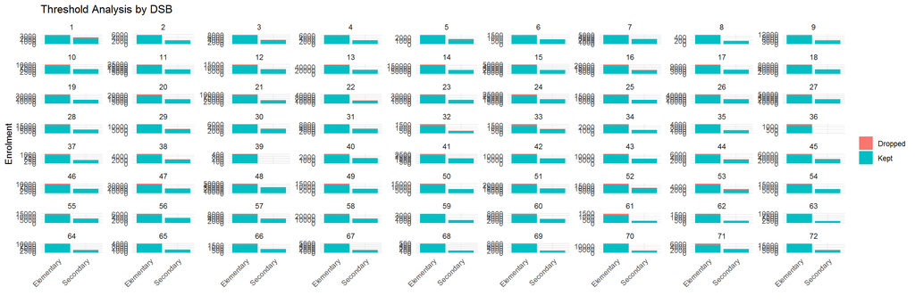

```r
schoolCatchmentThreshold <- schoolCatchment %>%
  uncount(enrolment) %>%
  group_by(school.name, school.lat, school.long) %>%
  summarise(
    lower_adj = boxplot.stats(dist)$stats[1],
    upper_adj = boxplot.stats(dist)$stats[5]
  )

schoolCatchment <- left_join(schoolCatchment, schoolCatchmentThreshold, by = c('school.name', 'school.lat', 'school.long')) %>%
  mutate(keep = as.factor(ifelse(dist <= upper_adj & dist >= lower_adj, 1, 0)))

# Plot stacked barplots of students within vs outside of threshold
schoolCatchment %>%
  uncount(enrolment) %>%
  ggplot(aes(x = panel, fill = keep)) +
  geom_bar() +
  facet_wrap(vars(dsb.index), scales = 'free_y')  +
  theme_minimal() +
  labs(x = '', y = 'Enrolment', title = 'Threshold Analysis by DSB') +
  scale_fill_discrete(name = '', labels = c('Dropped', 'Kept')) +
  theme(axis.text.x = element_text(angle = 45, hjust = 1))
```

```r
num_outlier_students <- sum(filter(schoolCatchment, keep == '0')$enrolment)
num_within_students <- sum(filter(schoolCatchment, keep == '1')$enrolment)
print(paste0('Dropped ', num_outlier_students, ' students because they fall outside of acceptable threshold range.'))
```

```
## [1] "Dropped 134036 students because they fall outside of acceptable threshold range."
```

```r
print(paste0('Kept ', num_within_students, ' students because they fall inside of acceptable threshold range.'))
```

```
## [1] "Kept 1802617 students because they fall inside of acceptable threshold range."
```

[figure not shown]

```r
schoolCatchment <- schoolCatchment %>%
  filter(keep == '1')

# schoolCatchment %>%
#   filter(panel == 'Secondary', dsb.index == 14) %>%
#   uncount(enrolment) %>%
#   ggplot(aes(x = school.name, y = dist)) +
#   geom_boxplot(outlier.color = 'red')
```

### Quick Check of ADE vs Enrollment

[figure not shown]

```r
# Check the enrollment total vs ADE numbers
temp1 <- schoolSFIS %>%
  select(bsid, school.name, ade, ade.forecast) %>%
  arrange(school.name)

temp2 <- studentPostSlim %>%
  group_by(bsid) %>%
  summarise(
    enrolment = sum(enrolment),
    school.name = first(school.name)
  ) %>%
  arrange(school.name)

temp <- left_join(temp1, temp2, by = "bsid") %>%
  drop_na(enrolment) %>%
  gather(key = 'key', value = 'value', ade, enrolment) %>%
  select(-school.name.y) %>%
  arrange(school.name.x) %>%
  mutate(facet_index = factor(row_number() %/% 100))

ggplot(data = temp, aes(fill = key, x = school.name.x, y = value)) +
  geom_bar(stat = "identity", position = 'dodge') +
  facet_wrap(~facet_index, ncol = 5, scales = 'free_x') +
  labs(x = '')
```

```r
rm(temp1, temp2, temp)
```

### Visualization of percentile travel distance

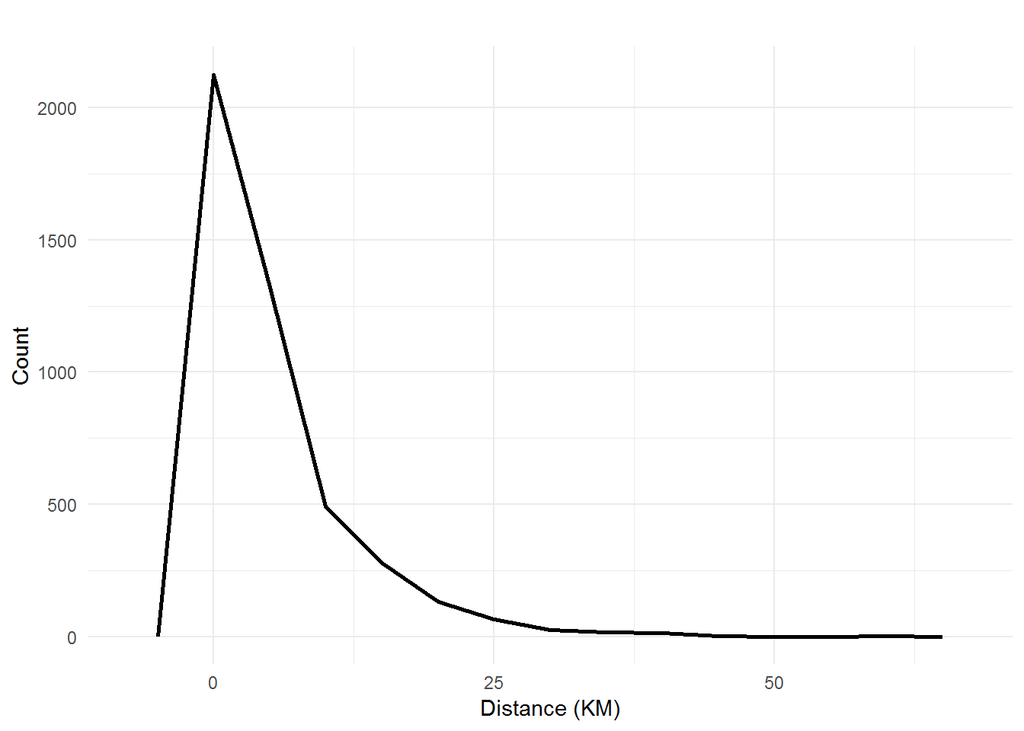

```r
student_travel <- readRDS(file = 'output/student_travel_0.9.rds') %>%
  as_tibble() %>%
  group_by(sfis, school.name, school.lat, school.long) %>%
  summarise(distance = first(perc.dist))

ggplot(data = student_travel, aes(distance)) +
  geom_freqpoly(stat = "bin", binwidth = 5, size = 1) +
  labs(x = "Distance (KM)", y = "Count", title = "") +
  theme_minimal()
```

## Clean and Simplify Portables Data

- Assume that portable units are rounded at 0.75. So a protable with 1.8 units is rounded 2 units and a portable with 1.7 units is rounded to 1 unit
- Assume that 23 elementary or 21 secondary students per unit of portable
- Update the utilization of each school after adding in the portables

```
## [1] "There are 488 schools with utilization greater than 1.2."
```

## Clean EQAO Data

```r
eqaoSlim <- eqao %>%
  select(School.Number, School.Name, School.Type, School.Level, School.Language, Enrolment, Latitude, Longitude)
```